# Insight IDX 20C Presession Data Excercise

#### Aaron C. Rizzuto

The first steps are to import all the packages I'll be using, read the dataset in with Pandas, and do some bery simple formatting.

```python
##I'm can't handle the auto-bracketing, turn it off! Apparently it only needs to be done once
#from notebook.services.config import ConfigManager
#c = ConfigManager()
#c.update('notebook', {"CodeCell": {"cm_config": {"autoCloseBrackets": False}}})
import sys,os,pickle
import numpy as np
import pandas as pd
import seaborn as sns
sns.set_style(style='ticks')
from scipy.interpolate import griddata as gd
import matplotlib.pyplot as plt
%matplotlib notebook
import matplotlib as mpl
mpl.rcParams['lines.linewidth']   = 2
mpl.rcParams['axes.linewidth']    = 2
mpl.rcParams['xtick.major.width'] = 2
mpl.rcParams['ytick.major.width'] = 2
mpl.rcParams['ytick.labelsize']   = 10
mpl.rcParams['xtick.labelsize']   = 10
mpl.rcParams['axes.labelsize']    = 14
mpl.rcParams['legend.numpoints']  = 1
mpl.rcParams['axes.labelweight']  = 'semibold'
mpl.rcParams['axes.titlesize']    = 9
mpl.rcParams['axes.titleweight']  = 'semibold'
mpl.rcParams['font.weight']       = 'semibold'


datafile = 'conversion_data.csv'
datain  = pd.read_csv(datafile)
data = datain.to_records() ##A numpy recarray for later use
odata=data.copy()##a copy of the bare data recarray incase bugshooting is nessecary

##Some of seaborns plotting functionality autosupresses non-numerical columns,
##so it makes life easier for plotting if the converted field is a string instead of integer type
##as I'll be splitting on it most likely.
qwe = np.where(datain.converted.values == 1)[0]
qwe2 =np.where(datain.converted.values == 0)[0]
datain['converted'] = datain['converted'].astype(str)
datain.converted.values[qwe] = 'Yes'
datain.converted.values[qwe2] = 'No'
```

#### Now Lets take a look at what some of the data entries and column names look like

```python
datain.head()
```

|  | country | age | new_user | source | total_pages_visited | converted |
| --- | --- | --- | --- | --- | --- | --- |
| 0 | UK | 25 | 1 | Ads | 1 | No |
| 1 | US | 23 | 1 | Seo | 5 | No |
| 2 | US | 28 | 1 | Seo | 4 | No |
| 3 | China | 39 | 1 | Seo | 5 | No |
| 4 | US | 30 | 1 | Seo | 6 | No |

#### What are the breakdowns of the different categorical fields?

tally the different value counts and distplay them as percentages of the full dataset.

```python
##breakdowns

print('Source Breakdown (%)')
print('-----')
print(np.round(datain['source'].value_counts()/len(datain)*100.0,decimals=2))
print('-----')
print('')
print('Country Breakdown (%)')
print('-----')
print(np.round(datain.country.value_counts()/len(datain)*100.0,decimals=2))
print('')
print('User Type Breakdown(%)')
print('-----')
print(np.round(datain.new_user.value_counts()[0:2]/len(datain)*100.0,decimals=2))
print('-----')
```

```
Source Breakdown (%)
-----
Seo       49.03
Ads       28.06
Direct    22.90
Name: source, dtype: float64
-----

Country Breakdown (%)
-----
US         56.32
China      24.23
UK         15.32
Germany     4.13
Name: country, dtype: float64

User Type Breakdown(%)
-----
1    68.55
0    31.45
Name: new_user, dtype: float64
-----
```

### First lets explore the numerical data, splitting on whether or not users converted.

Let's plot the distributions of user age and total pages visited

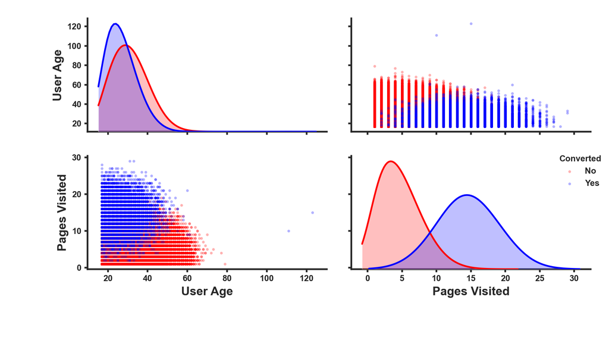

```python
###Lets explore some things, breaking down the sample by whether or not people converted
plotcols = ['age','total_pages_visited','converted']
plotstuff = sns.pairplot(datain[plotcols],hue = 'converted', height=1.4, aspect=1.5,palette={'Yes': "b", 'No': "r"},diag_kind='kde',diag_kws=dict(shade=True,bw=0.6),plot_kws=dict(edgecolor="black", linewidth=0.0,alpha=0.3,s=10))
plotstuff.axes[1,0].set_ylabel('Pages Visited')
plotstuff.axes[1,1].set_xlabel('Pages Visited')
plotstuff.axes[0,0].set_ylabel('User Age')
plotstuff.axes[1,0].set_xlabel('User Age')
plotstuff._legend.set_title('Converted')
plt.tight_layout()
```

### First Impressions Age and Page Numbers

1. There are two super old folks in this dataset, that are outliers in terms of any statistical inferences we would like to make. Excluding them might be a good idea prior to making a model to predict conversion rate.
2. People who bought something (converted=Yes) seem to visit significantly more pages than those who did not. This might be correlated in the other direction though poeple wo are going to buy might look at lots of pages after making the buy desicion (e.g. to see/compare versions of a product?)
3. Older people tend to both convert less often, and look at less pages

```
Total Conversion Rate: 3.22%
```

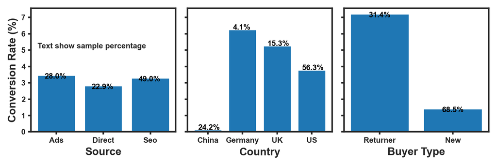

```python
##Lets plot the other categorical variables as bar plots, and see how they stack up towards converstion.

#counterplot = sns.countplot(x='source', hue='converted', data=datain, palette={'Yes': 'b', 'No': 'r'})
cc = np.where(datain.converted.values == 'Yes')[0]
nc = np.where(datain.converted.values == 'No')[0]
print('Total Conversion Rate: ' +str(len(cc)*1.0/len(datain)*100)[0:4] + '%')

##Source
x_values = [xx for xx in np.unique(datain.source.values)]
y_values = [len(np.where(datain.source.values[cc] == xx)[0])*1.0/len(np.where(datain.source.values==xx)[0])*100.0 for xx in x_values]

fig,(ax0,ax1,ax2) = plt.subplots(1,3,figsize=(9, 3),sharey=True)
ax0.bar(x_values,y_values)
ax0.set_ylabel('Conversion Rate (%)')
ax0.set_xlabel('Source')

for idx,ii in enumerate(ax0.patches):
    qwe = np.where(datain.source == x_values[idx])[0]
    ax0.text(ii.get_x()+0.15, ii.get_height()-0.2,str(len(qwe)*1.0/len(datain)*100)[0:4]+'%', fontsize=10,color='black')

##Country
x_values = [xx for xx in np.unique(datain.country.values)]
y_values = [len(np.where(datain.country.values[cc] == xx)[0])*1.0/len(np.where(datain.country.values==xx)[0])*100.0 for xx in x_values]

#fig2,ax2 = plt.subplots()
ax1.bar(x_values,y_values)
#ax1.set_ylabel('Conversion Rate (%)')
ax1.set_xlabel('Country')
for idx,ii in enumerate(ax1.patches):
    qwe = np.where(datain.country == x_values[idx])[0]
    ax1.text(ii.get_x()+0.12, ii.get_height(),str(np.round(len(qwe)*1.0/len(datain)*100,decimals=1))+'%', fontsize=10,color='black')

##User Type
x_values = [xx  for xx in np.unique(datain.new_user.values)]
y_values = [len(np.where(datain.new_user.values[cc] == xx)[0])*1.0/len(np.where(datain.new_user.values==xx)[0])*100.0 for xx in x_values]
nx_values = ['Returner','New']

#fig3,ax3 = plt.subplots()
ax2.bar(nx_values,y_values)
#ax2.set_ylabel('Conversion Rate (%)')
ax2.set_xlabel('Buyer Type')
for idx,ii in enumerate(ax2.patches):
    qwe = np.where(datain.new_user == x_values[idx])[0]
    ax2.text(ii.get_x()+0.25, ii.get_height()-0.2,str(len(qwe)*1.0/len(datain)*100)[0:4]+'%', fontsize=10,color='black')
ax0.text(-0.4,5.1,'Text show sample percentage')
fig.tight_layout()
```

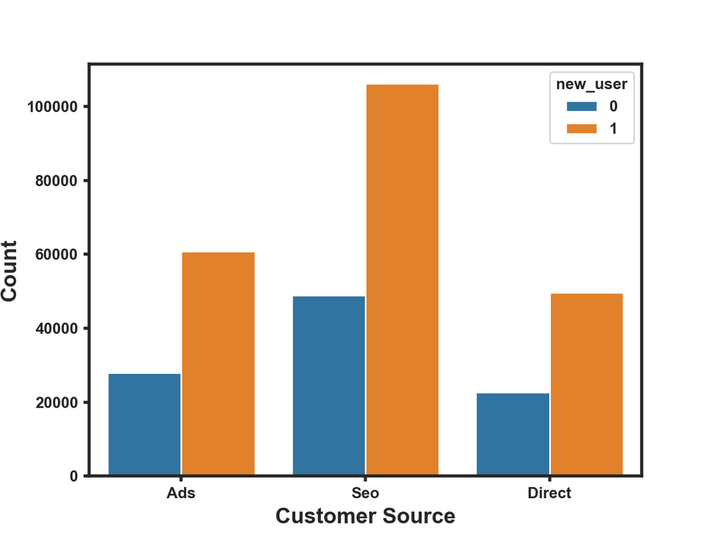

```python
figc,axc = plt.subplots()
sns.countplot(x='source',data=datain,hue='new_user')
axc.set_ylabel('Count')
axc.set_xlabel('Customer Source')
```

It seems that new and returning users are as likely as each other to arrive via the three source pathways. This might suggest that return customers are not being as aggresively marketed to as is ideal. I.e. they have to stumble upon and add or search result that reminds them of the product/company that they already like, rather than being reminded specifically.

### We can make a model to predict conversion using a Niave Bayes classifier.

Start with cleaning some outliers, then index categorical data to make it easier to use

```python
##there are two super old folks (>100) in here, both new customers, exclude as they are not useful for any real insight
##going to use the recarray version here so I don't have to type values all the time.
oldies = np.where(data.age > 90.0)[0] ##The two old users are above 100
clean = np.where(data.age < 90.)[0]
data=data[clean]
```

```python
##Flag converted and non-converted entries for later use.
conv  = np.where(data.converted == 1)[0]
nconv = np.where(data.converted == 0)[0]
```

```python
##lets index the categorical string type fields: source and country
sources   = np.unique(data.source)
sdict = dict(zip(sources,range(len(sources))))
countries = np.unique(data.country)
cdict = dict(zip(countries,range(len(countries))))
sindex = np.zeros(len(data),dtype=int)
cindex = np.zeros(len(data),dtype=int)
for i in range(len(data)):
    cindex[i] = cdict[data.country[i]]
    sindex[i] = sdict[data.source[i]]

print(cdict)
print(sdict)
```

```
{'China': 0, 'Germany': 1, 'UK': 2, 'US': 3}
{'Ads': 0, 'Direct': 1, 'Seo': 2}
```

### Lets make the Niave Bayes model.

We can turn it into a non-niave Bayes model later if we want by sample an N-dimensional histogram, probably not needed though. The positives of the niave model are the regions of joint probability space with no conversions or very few data points can be modelled from the niave distributions.

For each case in $$C_i$$ representing the cases for conversion and non-conversion
we can calculate the probability using Bayes theorem. $$P(C_i|Data) = P(C_i)P(Data|C_i)/P(Data)$$

with $$P(Data|C_i) = P(age|C_i)P(pages|C_i)P(Country|C_i)P(Source|C_i)P(NewUser|C_i)/P(Data)$$

Then the model likelihood ratio (converted to not-converted) is $$R = \frac{P(Conv)P(Data|Conv)}{P(NConv)P(Data|NConv)}$$

with the prior ratio $$\frac{P(Conv)}{P(Nconv)} $$ given by the global conversion rate Formulating this as a likelihood ratio is convenient as we can remove P(Data) which is often a complicated quantity to get right.

The probabilities for the categorical data are simple frequencies, and for the numerical fields (age, number of pages), we can use the histograms as estimates of the distribution PDF's. We could parametrize them, e.g. converted page numbers looks close to Gaussian, but the other distributions are definitely not that simple. Essentially we are making a multinomial Niave Bayes.

To make things slightly simpler again, testing points that fall outside of the bin ranges of our training set histograms will be assigned to the edge bins. This means points outside the training range that would get zero probability will get a small probability in this case. This is an ok approximation for now, but would be a problem if we needed to predict conversion for things well outside the bounds of the training set data.

```python
def prob_data_given_model(histage,histpage,cind,sind,new_user,testpoint):
    '''
    Training Set Data:

    histage and histpage are 2 element tuples, which are the output of the numpy histogram functions on the
    user age and page visits data.

    cind and sind are the training set country and source indexes
    new_user is the user type flag of the training set data

    testpoint is a list of parameters of a point you want the probability of conversion for.
    [age,country,source,newuser,numpages]

    '''
    ##make the age histogram first
    agehist,agebins = histage
    ##compute the component probabilities:
    ad = agebins-testpoint[0]
    closest = np.where(ad <= 0)[0]
    if len(closest) == 0:
        closest = 0
    else: closest = closest[-1]
    if closest > len(agehist)-1: closest = -1
    p_age_model = agehist[closest]

    p_country_model = len(np.where(cind == testpoint[1])[0])*1.0/len(cind)

    p_source_model  = len(np.where(sind == testpoint[2])[0])*1.0/len(sind)

    p_new_model = len(np.where(new_user == testpoint[3])[0])*1.0/len(new_user)

    ##make page visit histogram:
    pagehist,pagebins = histpage

    pd = pagebins - testpoint[4]

    closest = np.where(pd <= 0)[0]
    if len(closest) == 0:
        closest = 0
    else: closest = closest[-1]
    if closest > len(pagehist)-1: closest = -1

    p_page_model = pagehist[closest]

    return p_page_model*p_new_model*p_source_model*p_country_model*p_age_model
```

```python
## run a test point through the model
global_prior = len(conv)*1.0/len(data)
print('Prior ' + str(global_prior))

tpoint = [20,3,0,0,20] ##age,country,source,newuser,pages
##This testpoint should convert given the young age, source locatoin and large page numbers.
prob_given_conv = prob_data_given_model(np.histogram(data.age[conv],bins=20,density=True),np.histogram(data.total_pages_visited[conv],bins=15,density=True),cindex[conv],sindex[conv],data.new_user[conv],tpoint)

prob_given_nconv  = prob_data_given_model(np.histogram(data.age[nconv],bins=20,density=True),np.histogram(data.total_pages_visited[nconv],bins=15,density=True),cindex[nconv],sindex[nconv],data.new_user[nconv],tpoint)

model_lk_rat = prob_given_conv/prob_given_nconv*global_prior
print('prob(D|model convert): ' + str(prob_given_conv))
print('prob(D|model noconvert): ' + str(prob_given_nconv))
print('model likelihood ratio (convert/not_convert): ' + str(model_lk_rat)[0:5])
print('probability of conversion: ' + str(model_lk_rat/(1+model_lk_rat)*100)[0:4] + '%')
```

```
Prior 0.03225194340255157
prob(D|model convert): 0.00027690536761553597
prob(D|model noconvert): 3.001652912216299e-08
model likelihood ratio (convert/not_convert): 297.5
probability of conversion: 99.6%
```

### Test the model:

We will use two thirds of the initial dataset as a training sample, and the remaining third as a testing set.

##### Note we only run this next code block once to save time, skip ahead!

```python
##seems like randomizing ins't really needed here
#makechoice = np.random.choice(len(data.index),len(data.index),replace=False)

trainset = np.array(range(int(len(data)/3.0*2.0)))
testset  = np.array(range(int(len(data)/3.0*2.0),len(data)))
tc = np.where(data.converted[trainset] == 1)[0]
tn = np.where(data.converted[trainset] == 0)[0]
prior = len(tc)*1.0/len(trainset)

histage_conv = np.histogram(data.age[trainset[tc]],bins=20,density=True)
histage_nconv = np.histogram(data.age[trainset[tn]],bins=20,density=True)
histpage_conv = np.histogram(data.total_pages_visited[trainset[tc]],bins=15,density=True)
histpage_nconv = np.histogram(data.total_pages_visited[trainset[tn]],bins=15,density=True)

convprob = np.zeros(len(testset),dtype=float)
for i in range(0,len(testset)):
    if i % 1000 == 0 :
        print('Up to ' + str(i) + ' out of '  + str(len(testset)))
        sys.stdout.flush()
    tpoint = [data.age[testset[i]],cindex[testset[i]],sindex[testset[i]],data.new_user[testset[i]],data.total_pages_visited[testset[i]]]
    prob_given_conv = prob_data_given_model(histage_conv,histpage_conv,cindex[trainset[tc]],sindex[trainset[tc]],data.new_user[trainset[tc]],tpoint)
    prob_given_nconv  = prob_data_given_model(histage_nconv,histpage_nconv,cindex[trainset[tn]],sindex[trainset[tn]],data.new_user[trainset[tn]],tpoint)

    model_lk_rat = prob_given_conv/prob_given_nconv*prior
    convprob[i] = model_lk_rat/(1+model_lk_rat)

fff=open('tmp_modelsave_py3.pkl','wb')
pickle.dump((testset,convprob),fff)
fff.close()
```

```python
##Read in the testing set model run
fff = open('tmp_modelsave_py3.pkl','rb')
testset,convprob = pickle.load(fff)
fff.close()
```

### How good is the model?

We can use the testing set (the last third of the original dataset) to estimate this.  
First, set a cutoff probability of conversion, lets say 50% conversion probability, we can then see what fraction of the test set we correctly classified.

```python
cutoff = 0.5
modc = np.where(convprob >= cutoff)[0]
modnc =np.where(convprob < cutoff)[0]
assignment = np.zeros(len(testset),dtype=int)
assignment[modc] = 1
qwe = np.where(assignment - data[testset].converted == 0)[0] ##positive hits



print('Model Assignment Accuracy: ' + str(np.around(len(qwe)*1.0/len(testset)*100,decimals=2)) + '%')
##fscore:
from sklearn.metrics import f1_score
fscore = f1_score(assignment,data[testset].converted)
print('F Score: ' + str(fscore)[0:6])
```

```
Model Assignment Accuracy: 98.59%
F Score: 0.7642
```